# Analysis of 2016 Hate Crime Database

Farhod Ibragimov

2025-02-02

Loading required packages:

## Loading data

Let’s load data from .csv file obtained from FiveThirtyEight.

Reference: (“https://raw.githubusercontent.com/fivethirtyeight/data/master/hate-crimes/hate_crimes.csv”):

```r
hate_crimes <- read.csv("https://raw.githubusercontent.com/fivethirtyeight/data/master/hate-crimes/hate_crimes.csv", header = TRUE)
glimpse(hate_crimes)
```

```
## Rows: 51
## Columns: 12
## $ state                                    <chr> "Alabama", "Alaska", "Arizona…
## $ median_household_income                  <int> 42278, 67629, 49254, 44922, 6…
## $ share_unemployed_seasonal                <dbl> 0.060, 0.064, 0.063, 0.052, 0…
## $ share_population_in_metro_areas          <dbl> 0.64, 0.63, 0.90, 0.69, 0.97,…
## $ share_population_with_high_school_degree <dbl> 0.821, 0.914, 0.842, 0.824, 0…
## $ share_non_citizen                        <dbl> 0.02, 0.04, 0.10, 0.04, 0.13,…
## $ share_white_poverty                      <dbl> 0.12, 0.06, 0.09, 0.12, 0.09,…
## $ gini_index                               <dbl> 0.472, 0.422, 0.455, 0.458, 0…
## $ share_non_white                          <dbl> 0.35, 0.42, 0.49, 0.26, 0.61,…
## $ share_voters_voted_trump                 <dbl> 0.63, 0.53, 0.50, 0.60, 0.33,…
## $ hate_crimes_per_100k_splc                <dbl> 0.12583893, 0.14374012, 0.225…
## $ avg_hatecrimes_per_100k_fbi              <dbl> 1.8064105, 1.6567001, 3.41392…
```

We can see that this dataset has 51 observation points, and 12 variables.

## Correlation analysis.

```r
numeric_data <- hate_crimes |>
  select_if(is.numeric)
```

```r
corr_hate_crimes <- cor(numeric_data, use = "complete.obs")
```

```r
melted_hate_crimes <- melt(corr_hate_crimes)
```

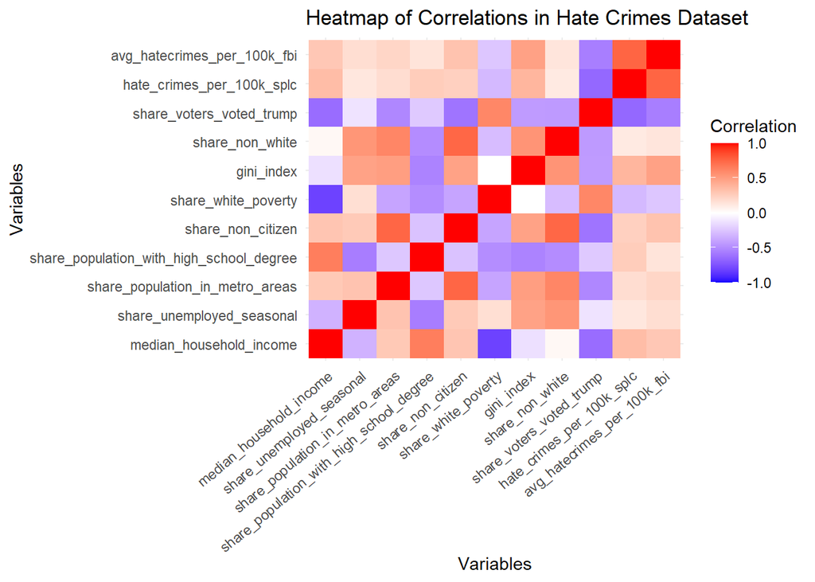

```r
ggplot(melted_hate_crimes, aes(x = Var1, y = Var2, fill = value)) +
  geom_tile() +
  scale_fill_gradient2(low = "blue", high = "red", mid = "white",
                       midpoint = 0, limit = c(-1,1), space = "Lab",
                       name="Correlation") +
  theme_minimal() +
  theme(axis.text.x = element_text(angle = 40, vjust = 1, hjust = 1)) +
  labs(title = "Heatmap of Correlations in Hate Crimes Dataset",
       x = "Variables",
       y = "Variables")
```

Correlation values closer to 1 show positive correlation, and closer to -1 indicate negative correlation.

Values close to 0 indicate that there is no significant correlation.

Let’s explore some strong positive and negative correlations

## Including Plots

1. Let’s make a scatter plot to see relationship between share of white poverty and median household income

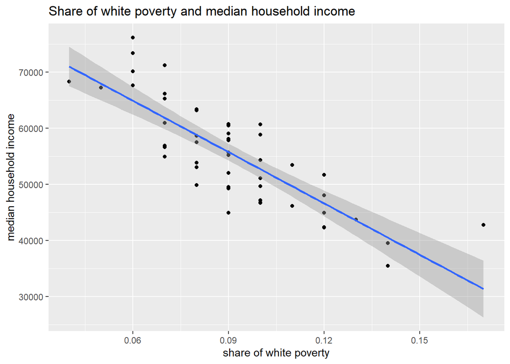

```r
ggplot(hate_crimes, aes(x = share_white_poverty, y = median_household_income)) +
  geom_point() +
  geom_smooth(method = "lm")+
  labs(
    title = "Share of white poverty and median household income",
    x = "share of white poverty",
    y = "median household income"
  )
```

The conclusion from this scatter plot is that increase in share of white poverty (explanatory variable) has a negative effect on median household income (response variable).

2. Let’s compare share of population in metro areas with share of non-citizens:

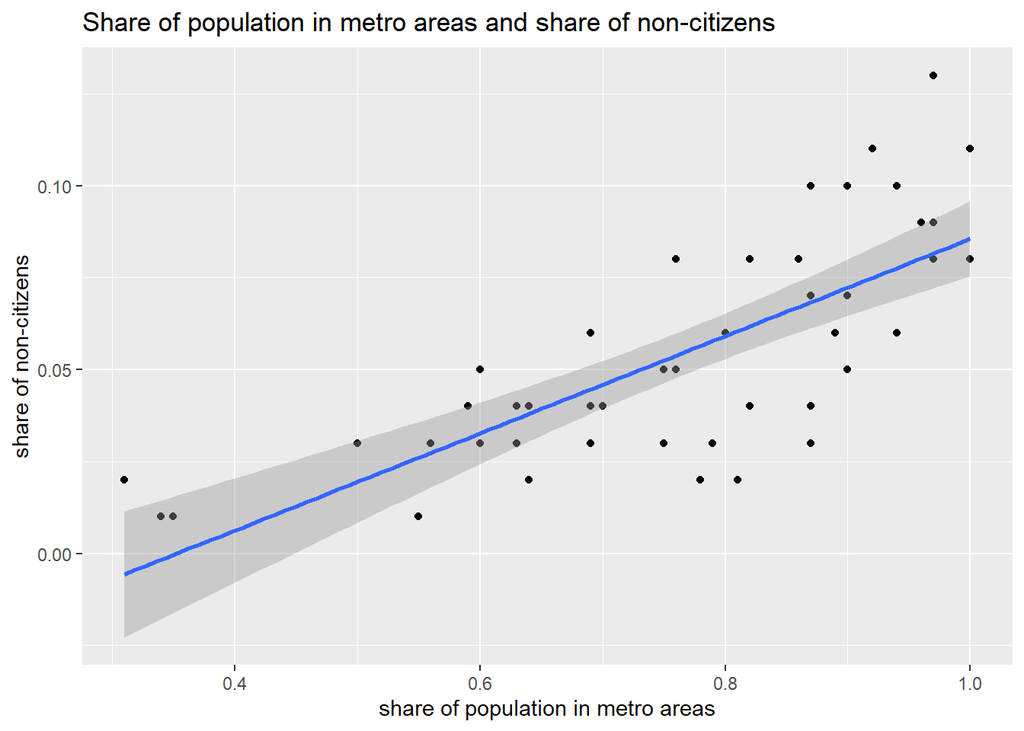

```r
ggplot(numeric_data, aes(x = share_population_in_metro_areas, y = share_non_citizen)) +
  geom_point(na.rm = TRUE)+
  geom_smooth(method = "lm") +
  labs(
    title = "Share of population in metro areas and share of non-citizens",
    x = "share of population in metro areas",
    y = "share of non-citizens"
  )
```

In this scatter plot we can see that there is a positive relationship in share of population in metro area (explanatory) and share of non-citizens (response).

3. Let’s see how median household income related to share of voters voted for President Trump in 2016:

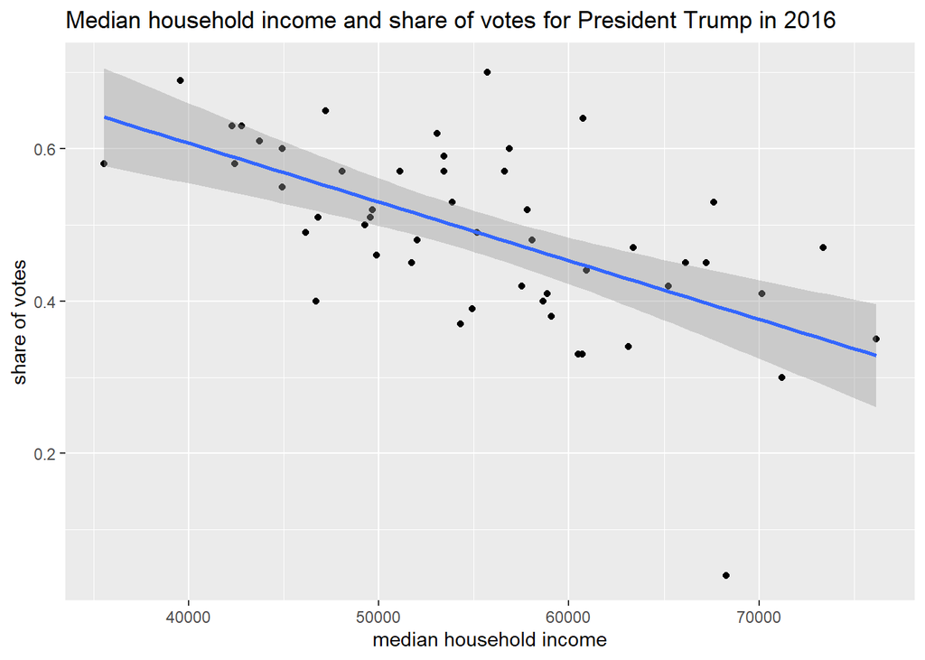

```r
ggplot(hate_crimes, aes(x = median_household_income, y = share_voters_voted_trump)) +
  geom_point(na.rm = TRUE) +
  geom_smooth(method = "lm") +
  labs(
    title = "Median household income and share of votes for President Trump in 2016",
    x = "median household income",
    y = "share of votes"
  )
```

Here we can see that increase in median household income (explanatory variable) had a negative effect on share of voters voted for President Trump (response variable) in 2016.

4. Let’s see relationship between GINI index and share of population with high school degree:

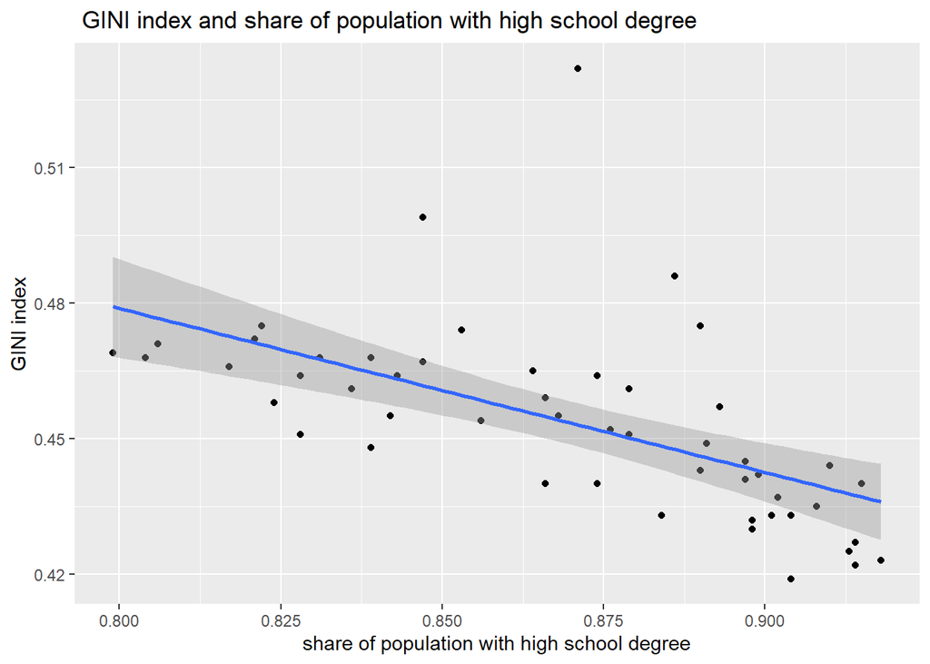

```r
ggplot(hate_crimes, aes(x = share_population_with_high_school_degree, y = gini_index)) +
  geom_point(na.rm = TRUE) +
  geom_smooth(method = "lm") +
  labs(
    title = " GINI index and share of population with high school degree",
    x = "share of population with high school degree",
    y = "GINI index"
  )
```

The GINI index is used to measure income inequality, wealth inequality, or consumption inequality. A GINI index of 0 represents perfect equality, while an index of 1 implies perfect inequality.

We can see that increase in share of population with high school diploma (explanatory variable) has a negative impact on GINI index (response variable).

5. Let’s create a bar chart for each state count of hate crime for 100K of population per FBI.

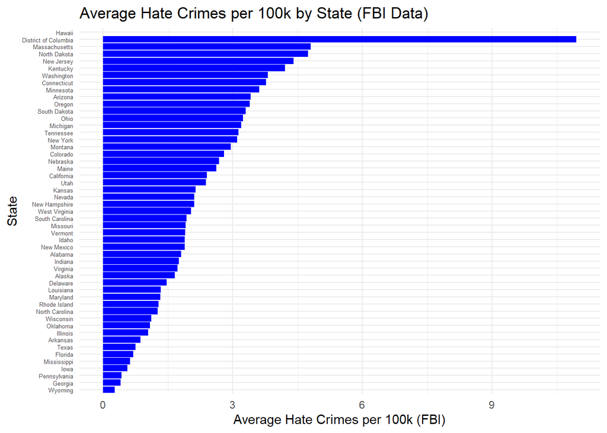

   ```r
   hate_crimes <- hate_crimes |>
     arrange(avg_hatecrimes_per_100k_fbi)


   ggplot(hate_crimes, aes(x = avg_hatecrimes_per_100k_fbi, y = reorder(state, avg_hatecrimes_per_100k_fbi))) +
     geom_col(fill = "blue") +
     labs(
       x = "Average Hate Crimes per 100k (FBI)",
       y = "State",
       title = "Average Hate Crimes per 100k by State (FBI Data)"
     ) +
     theme_minimal() +
     theme(
       axis.text.y = element_text(size = 5, lineheight = 20)
     )
   ```

This bar chart shows average hate crimes per 100K of population in each state. This data came from FBI.

According to this article https://fivethirtyeight.com/features/higher-rates-of-hate-crimes-are-tied-to-income-inequality/, not all hate crimes included in FBI data. For example, non-prosecuted hate crimes are usually not included in FBI data. Also, many people do not report hate crimes. And we can make a conclusion that this data from FBI is not validated and is not reliable.  
\pagebreak